# Question

A quadratic function, with two [real](https://en.wikipedia.org/wiki/Real_number) [roots](https://en.wikipedia.org/wiki/Zero_of_a_function), is graphed below.

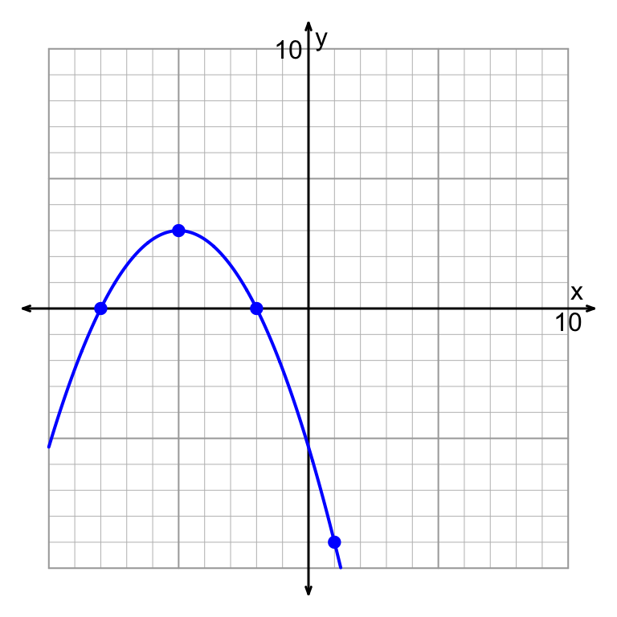

What equation represents the function in factored form?

## Answerlist

- $y=\frac{-1}{3}(x-{8})(x-{2})$
- $y=\frac{-1}{3}(x-{8})(x+{2})$
- $y=\frac{-1}{3}(x+{8})(x-{2})$
- $y=\frac{-1}{3}(x+{8})(x+{2})$
- $y=\frac{-1}{4}(x-{8})(x-{2})$
- $y=\frac{-1}{4}(x-{8})(x+{2})$
- $y=\frac{-1}{4}(x+{8})(x-{2})$
- $y=\frac{-1}{4}(x+{8})(x+{2})$
- $y=\frac{1}{3}(x-{8})(x-{2})$
- $y=\frac{1}{3}(x-{8})(x+{2})$
- $y=\frac{1}{3}(x+{8})(x-{2})$
- $y=\frac{1}{3}(x+{8})(x+{2})$
- $y=\frac{1}{4}(x-{8})(x-{2})$
- $y=\frac{1}{4}(x-{8})(x+{2})$
- $y=\frac{1}{4}(x+{8})(x-{2})$
- $y=\frac{1}{4}(x+{8})(x+{2})$

# Solution

The correct answer is:
$$y=\frac{-1}{3}(x+{8})(x+{2})$$

You can determine $a$ by using [this reference sheet](https://artockthedino.github.io/algtwo2026/u06/1218/Stretched_Parabolas_Reference.html). You also need to remember that if $a<0$, then the parabola opens downward.

The roots are at $(-8,0)$ and $(-2,0)$. Thus, we could say $r=-8$ and $s=-2$ (or the other way around). We put those parameters into factored-form equation, $y=a(x-r)(x-s)$, to get…

$$y=\frac{-1}{3}(x+{8})(x+{2})$$

# Meta-information

extype: schoice exsolution: 0001000000000000 exname: factored_form_from_graph